# Logistic Regression

# Logistic Regression

Whereas Linear Regression can be used to predict a *continuous* variable, **Logistic Regression** allows us to make predictions where our dependent variable is a *categorical* variable.

The Logistic Function is given as

$$p(X) = \frac{\epsilon^{\beta_0 + \beta_1x_1 + \cdots+\beta_kx_k}}{1 + \epsilon^{\beta_0 + \beta_1x_1 + \cdots+\beta_kx_k}} \\
\text{Odds} = \frac{p(X)}{1-p(X)} = \epsilon^{\beta_0 + \beta_1x_1 + \cdots+\beta_kx_k} \\
\text{log(Odds)} = \text{log} \Bigg(\frac{p(X)}{1-p(X)} \Bigg) = \beta_0 + \beta_1x_1 + \cdots+\beta_kx_k$$
where:

- $p(X)$ only takes values between $0$ and $1$
- $p(X)/(1-p(X))$ is known as the *odds* and takes a value between $0$ and $\infty$
- $\text{log} \Bigg(\frac{p(X)}{1-p(X)} \Bigg)$ is known is *log-odds* or *logit*

```r
library(readr)
library(dplyr)
quality <- read_csv("~/Documents/Online Classes/analytics-edge/quality.csv")
glimpse(quality)
```

```
Observations: 131
Variables: 14
$ MemberID             <int> 1, 2, 3, 4, 5, 6, 7, 8, 9, 10, 11, 12, 13, 14, 15, 16,...
$ InpatientDays        <int> 0, 1, 0, 0, 8, 2, 16, 2, 2, 4, 6, 0, 0, 1, 6, 0, 2, 3,...
$ ERVisits             <int> 0, 1, 0, 1, 2, 0, 1, 0, 1, 2, 5, 0, 1, 1, 2, 0, 0, 0, ...
$ OfficeVisits         <int> 18, 6, 5, 19, 19, 9, 8, 8, 4, 0, 20, 7, 3, 20, 31, 8, ...
$ Narcotics            <int> 1, 1, 3, 0, 3, 2, 1, 0, 3, 2, 2, 4, 1, 3, 3, 0, 0, 1, ...
$ DaysSinceLastERVisit <dbl> 731.0000, 411.0000, 731.0000, 158.0000, 449.0000, 731....
$ Pain                 <int> 10, 0, 10, 34, 10, 6, 4, 5, 5, 2, 9, 0, 23, 16, 70, 0,...
$ TotalVisits          <int> 18, 8, 5, 20, 29, 11, 25, 10, 7, 6, 31, 7, 4, 22, 39, ...
$ ProviderCount        <int> 21, 27, 16, 14, 24, 40, 19, 11, 28, 21, 19, 8, 13, 18,...
$ MedicalClaims        <int> 93, 19, 27, 59, 51, 53, 40, 28, 20, 17, 43, 23, 18, 48...
$ ClaimLines           <int> 222, 115, 148, 242, 204, 156, 261, 87, 98, 66, 126, 41...
$ StartedOnCombination <lgl> FALSE, FALSE, FALSE, FALSE, FALSE, FALSE, FALSE, FALSE...
$ AcuteDrugGapSmall    <int> 0, 1, 5, 0, 0, 4, 0, 0, 0, 0, 2, 2, 0, 0, 0, 0, 0, 3, ...
$ PoorCare             <int> 0, 0, 0, 0, 0, 1, 0, 0, 1, 0, 0, 0, 0, 0, 0, 0, 0, 1, ...
```

Create a `table` to see how many patients received poor care (`PoorCare = 1`) vs good care (`PoorCare = 0`):

```r
table(quality$PoorCare)
```

```
 0  1
98 33
```

# Create a Training and Test set

Use the `sample.split` function from the `caTools` package to randomly split the data into a training set and test set:

```r
library(caTools)
set.seed(88)
split <- sample.split(quality$PoorCare, SplitRatio = 0.75)
```

The `SplitRatio` argument indicates what percentage of the dataset you would like to have in the training set. By selecting 0.75, we are essentially calling the function to randomly select patients such that 75% of patients in our *training* set have ‘good’ care and 75% in our *testing* set have ‘good’ care.

**How would we split the dataset up if we were working with a *continuous* dependent variable instead?**

Use the `sample` function and the `size` argument.

```
df_split <- sample(1:nrow(df), size=0.75 * nrow(df))

df_train <- data[df_split,]
df_test <- data[-df_split,]
```

Now that you’ve randomly assigned patients to the training and test sets, go ahead and create each dataset:

```r
quality_train <- subset(quality, split == TRUE)
quality_test <- subset(quality, split == FALSE)
nrow(quality_train)
```

```
[1] 99
```

```r
nrow(quality_test)
```

```
[1] 32
```

```
# Alternative approach using filter()
qualityTrain <- quality %>% filter(split == TRUE)
qualityTest <- quality %>% filter(split == FALSE)
```

# Create a Logistic Regression Model

Use the `glm` function, which stands for *generalized linear model*:

```r
quality_train_model <- glm(PoorCare ~ OfficeVisits + Narcotics, data = quality_train, family = binomial)
summary(quality_train_model)
```

```
Call:
glm(formula = PoorCare ~ OfficeVisits + Narcotics, family = binomial,
    data = quality_train)

Deviance Residuals:
     Min        1Q    Median        3Q       Max
-2.06303  -0.63155  -0.50503  -0.09689   2.16686

Coefficients:
             Estimate Std. Error z value Pr(>|z|)
(Intercept)  -2.64613    0.52357  -5.054 4.33e-07 ***
OfficeVisits  0.08212    0.03055   2.688  0.00718 **
Narcotics     0.07630    0.03205   2.381  0.01728 *
---
Signif. codes:  0 ‘***’ 0.001 ‘**’ 0.01 ‘*’ 0.05 ‘.’ 0.1 ‘ ’ 1

(Dispersion parameter for binomial family taken to be 1)

    Null deviance: 111.888  on 98  degrees of freedom
Residual deviance:  89.127  on 96  degrees of freedom
AIC: 95.127

Number of Fisher Scoring iterations: 4
```

The AIC value is a measure of the quality of the model. The limitation is that it can only be used to compare models on the *same* data set. It acts like the *adjusted* $R^2$ that we dealt with in Linear Regression models in that it accounts for the number of variables used compared to the total number of observations.

# Make Predictions

```r
pred_quality_train <- predict(quality_train_model, type = "response")
summary(pred_quality_train)
```

```
   Min. 1st Qu.  Median    Mean 3rd Qu.    Max.
0.06623 0.11912 0.15967 0.25253 0.26765 0.98456
```

Using `type = "response"` tells the `predict` function to give us probabilities.

**Are we predicting probabilities for the ‘poor’ care cases (as we’d expect)?**

```r
tapply(pred_quality_train, quality_train$PoorCare, mean)
```

```
        0         1
0.1894512 0.4392246
```

# Thresholding

The outcome of a logistic regression model gives a probability, but we would like to convert this to a *discrete* value, e.g. a binary prediction (‘good’ vs ‘bad’ care). This is done by classifying the probability, $p(X)$, based on a **threshold value**, $t$.

You run into the possibility of Type I (FP) or Type II (FN) error depending on where you set your *threshold value*. This is often represented by a *confusion matrix* (aka *classification matrix*) predicted vs actual classification.

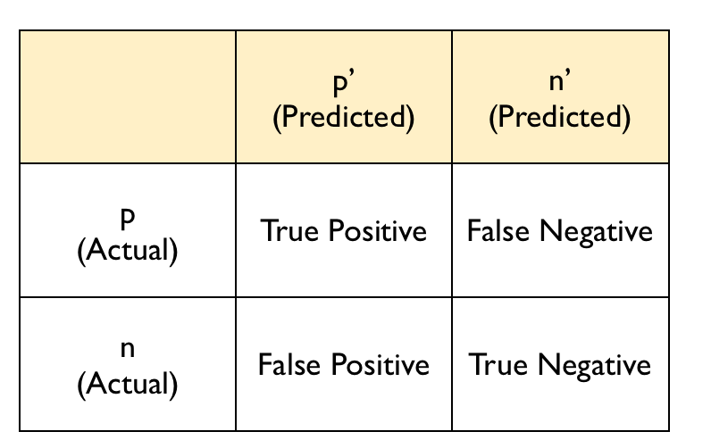

Recall,

- **Sensitivity** (aka *true positive rate*) is calculated as $TP/(TP + FN)$. In other words, is the proportion of TP to all the *actual* positives.
- **Specificity** (aka *true negative rate*) is calculated as $TN/(TN + FP)$. In other words, is the proportion of TN to all the *actual* negatives.
- **PPV** is given by $TP/(TP + FP)$
- **NPV** is given by $TN/(TN + FN)$

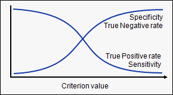

A model with a *higher* threshold value will have a *lower* sensitivity and a *higher* specificity (and vice versa).

## Example: Threshold value 0.5

```r
table(quality_train$PoorCare, pred_quality_train > 0.5)
```

```
    FALSE TRUE
  0    70    4
  1    15   10
```

In this example, we *correctly* predict 70 cases as being ‘good’ care, but 4 “actual” patients receiving ‘good’ care were incorrectly recorded as receiving ‘poor’ care based on our model at the 0.5 threshold value. Additionally, we have incorrectly labeled 15 pts who are actually receiving ‘poor’ care as receiving ‘good’ care.

In this example,

- Sensitivity = $10/(10 + 15)$ or $0.40$
- Specificity = $70/(70 + 4)$ or $0.95$

## Example: Threshold value 0.7

```r
table(quality_train$PoorCare, pred_quality_train > 0.7)
```

```
    FALSE TRUE
  0    73    1
  1    17    8
```

In this example,

- Sensitivity = $8/(8 + 17)$ or $0.32$
- Specificity = $73/(73 + 1)$ or $0.99$

Referring back to our Sensitivity and Specificity curves at different threshold values, this is consistent. Increasing our threshold value, $t$, from $0.5$ to $0.7$ caused sensitivity to decrease and specificity to increase.

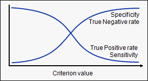

As shown in the next example, decreasing our threshold value results in sensitivity to increase and specificity to decrease.

## Example: Threshold value 0.2

```r
table(quality_train$PoorCare, pred_quality_train > 0.2)
```

```
    FALSE TRUE
  0    54   20
  1     9   16
```

In this example,

- Sensitivity = $16/(16 + 9)$ or $0.64$
- Specificity = $54/(54 + 20)$ or $0.73$

# ROC Curves

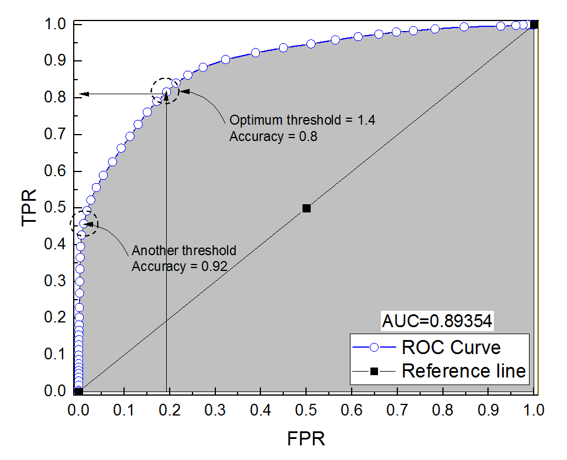

Recall,

- **True Positive rate** is another term for Sensitivity
- **False Positive rate** ($= FP/(TN + FP)$) is the same thing as $1 - \text{Specificity}$, which is true given that $\text{Specificity} = TN/(TN + FP)$
- **High Threshold** results in *high* specificity, but *low* sensitivity
- **Low Threshold** results in *low* specificty, but *high* sensitivity

## Make an ROC Curve

Use the `ROCR` or `pROC` package and the prediction function from our training set, `predictTrain` to generate an ROC curve:

### ROCR package

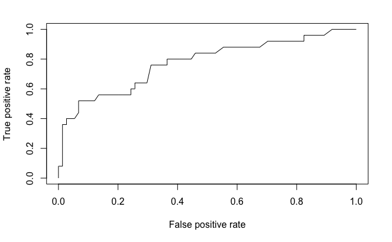

```r
library(ROCR)
ROCR_pred <- prediction(pred_quality_train, quality_train$PoorCare)
# argument 1 is our model predictions
# argument 2 is the actual/true outcomes from dataset the model is based off of
ROCR_perf <- performance(ROCR_pred, "tpr", "fpr")
plot(ROCR_perf)
```

- Add color by setting the argument `colorize = TRUE` in the `plot` function
- Add threshold values to the plot using the following arguments: `print.cutoffs.at=seq(0,1,by=0.1)` and `text.adj=c(-0.2,1.7)`

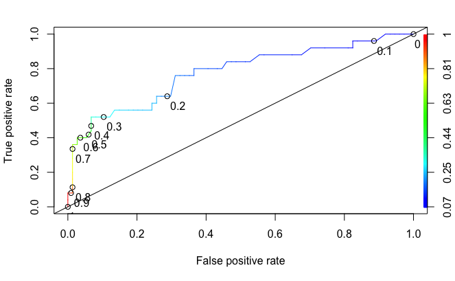

```r
plot(ROCR_perf,
     colorize=TRUE,
     print.cutoffs.at=seq(0,1,by=0.1),
     text.adj=c(-0.2,1.7)
     )
abline(a=0, b= 1) # reference line
```

### pROC package

Unlike with the `prediction` function of the `ROCR` package, with `roc` function of the `pROC` package, your first argument is the response variable from the training/test set and the second argument is the predicted model.

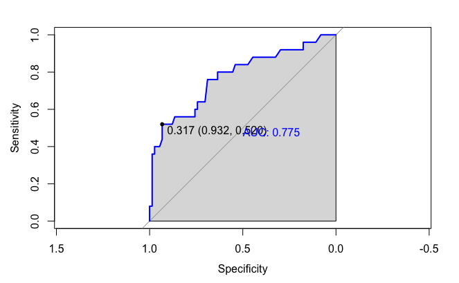

```r
library(pROC)
pROC_train <- roc(quality_train$PoorCare, pred_quality_train)
plot(pROC_train, col="blue",
     print.thres = "best",
     print.auc = TRUE,
     auc.polygon = TRUE,
     )
```

```r
#print.auc argument prints out the value of AUC
#auc.polygon argument shades in the AUC
```

`pROC` can be used to find the “best” threshold value. The package offers 2 different methods - `youden` (default) and `closest.topleft`.

```r
coords(pROC_train, "best")
```

```
  threshold specificity sensitivity
  0.3173387   0.9324324   0.5200000
```

```r
coords(pROC_train, "best",
       ret = c("threshold", "specificity", "sensitivity"),
       best.method = "closest.topleft"
       )
```

```
  threshold specificity sensitivity
  0.1941885   0.6891892   0.7600000
```

The thing I like about the `pROC` package is just how easy it is to get the desired values based on threshold values:

```r
# For the 'best' threshold value:
coords(pROC_train, "best", ret = c("threshold", "specificity", "sensitivity", "accuracy", "tn", "tp", "fn", "fp", "npv", "ppv", "1-specificity", "1-sensitivity", "1-accuracy", "1-npv", "1-ppv", "precision", "recall"))
```

```
    threshold   specificity   sensitivity      accuracy            tn            tp
   0.31733871    0.93243243    0.52000000    0.82828283   69.00000000   13.00000000
           fn            fp           npv           ppv 1-specificity 1-sensitivity
  12.00000000    5.00000000    0.85185185    0.72222222    0.06756757    0.48000000
   1-accuracy         1-npv         1-ppv     precision        recall
   0.17171717    0.14814815    0.27777778    0.72222222    0.52000000
```

```r
# For a select threshold value, e.g. 0.5:
coords(pROC_train, 0.5, ret = c("threshold", "specificity", "sensitivity", "accuracy", "tn", "tp", "fn", "fp", "npv", "ppv", "1-specificity", "1-sensitivity", "1-accuracy", "1-npv", "1-ppv", "precision", "recall"))
```

```
    threshold   specificity   sensitivity      accuracy            tn            tp
   0.50000000    0.94594595    0.40000000    0.80808081   70.00000000   10.00000000
           fn            fp           npv           ppv 1-specificity 1-sensitivity
  15.00000000    4.00000000    0.82352941    0.71428571    0.05405405    0.60000000
   1-accuracy         1-npv         1-ppv     precision        recall
   0.19191919    0.17647059    0.28571429    0.71428571    0.40000000
```

# Interpreting the Model

## Multicollinearity

Recall, this occurs when there is high correlation between independent variables. To test this, check the correlation between the independent variables.

## Area Under the Curve

Significance can be determined by looking at the Area Under the Curve (AUC) of our ROC curve, which is a measure of the quality of prediction. A perfect model would give an AUC of $1.00$ or $100$%.

### ROCR package

Using the `ROCR` package and the argument `measure = “auc”, we can calculate the AUC of our model:

```r
AUCperf <- performance(ROCR_pred, measure = "auc")
AUCperf@y.values
```

```
[[1]]
[1] 0.7745946
```

### pROC package

Just use the `auc` function and pass the roc argument in it:

```r
auc(pROC_train)
```

```
Area under the curve: 0.7746
```

```r
# Alternative would be auc(qualityTrain$PoorCare, predictTrain), but we already
# defined pROC_train as roc(qualityTrain$PoorCare, predictTrain), so we can pass that
# and get the same result
```

## Accuracy

Accuracy is another outcome measure to assess the model and is given by the formula:

$$\text{Accuracy} = \frac{TN + TP}{N}$$
where $N$ is the number of total observations

Accuracy can easily be calculated using the `ROCR` package by using the `measure = "acc"` argument:

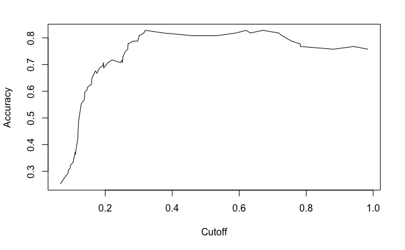

```r
accuracy_perf <- performance(ROCR_pred, measure = "acc")
plot(accuracy_perf)
```

We can then determine the threshold value that corresponds with the *maximum* accuracy. As seen in the figure above, our cutoff corresponds with the `x.values` and accuracy with `y.values`.

```r
# Get index that maximizes accuracy
ind <- which.max( slot(accuracy_perf, "y.values")[[1]] )
# Calculate accuracy value at the determined index
acc <- slot(accuracy_perf, "y.values")[[1]][ind]
# Calculate the corresponding cutoff at the determined index
cutoff <- slot(accuracy_perf, "x.values")[[1]][ind]
print(c(index = ind, accuracy= acc, cutoff = cutoff))
```

[output not shown]

# Example: Test Set

Compute the *test* set predictions:

```r
pred_quality_test <- predict(quality_train_model, type="response", newdata=quality_test)
```

Compute the AUC for the *test* set model you just created:

**with `ROCR` package**:

```r
ROCR_pred_test <- prediction(pred_quality_test, quality_test$PoorCare)
AUC_test <- performance(ROCR_pred_test, measure = "auc")
AUC_test@y.values
```

```
[[1]]
[1] 0.7994792
```

**with `pROC` package**

```r
auc(quality_test$PoorCare, pred_quality_test)
```

```
Area under the curve: 0.7995
```

# Framingham Study Example

> The term *risk factor* was coined by Drs. William Kannell and Roy Dawber of the Framingham Heart Study

**Load the dataset**:

```r
framingham <- read_csv("~/Documents/Online Classes/analytics-edge/framingham.csv")
glimpse(framingham)
```

```
Observations: 4,240
Variables: 16
$ male            <int> 1, 0, 1, 0, 0, 0, 0, 0, 1, 1, 0, 0, 1, 0, 0, 0, 1, 0, 0, 1,...
$ age             <int> 39, 46, 48, 61, 46, 43, 63, 45, 52, 43, 50, 43, 46, 41, 39,...
$ education       <int> 4, 2, 1, 3, 3, 2, 1, 2, 1, 1, 1, 2, 1, 3, 2, 2, 3, 2, 2, 2,...
$ currentSmoker   <int> 0, 0, 1, 1, 1, 0, 0, 1, 0, 1, 0, 0, 1, 0, 1, 1, 1, 1, 1, 0,...
$ cigsPerDay      <int> 0, 0, 20, 30, 23, 0, 0, 20, 0, 30, 0, 0, 15, 0, 9, 20, 10, ...
$ BPMeds          <int> 0, 0, 0, 0, 0, 0, 0, 0, 0, 0, 0, 0, 0, 1, 0, 0, 0, 0, 0, 0,...
$ prevalentStroke <int> 0, 0, 0, 0, 0, 0, 0, 0, 0, 0, 0, 0, 0, 0, 0, 0, 0, 0, 0, 0,...
$ prevalentHyp    <int> 0, 0, 0, 1, 0, 1, 0, 0, 1, 1, 0, 0, 1, 1, 0, 1, 1, 0, 0, 0,...
$ diabetes        <int> 0, 0, 0, 0, 0, 0, 0, 0, 0, 0, 0, 0, 0, 0, 0, 0, 0, 0, 0, 0,...
$ totChol         <int> 195, 250, 245, 225, 285, 228, 205, 313, 260, 225, 254, 247,...
$ sysBP           <dbl> 106.0, 121.0, 127.5, 150.0, 130.0, 180.0, 138.0, 100.0, 141...
$ diaBP           <dbl> 70.0, 81.0, 80.0, 95.0, 84.0, 110.0, 71.0, 71.0, 89.0, 107....
$ BMI             <dbl> 26.97, 28.73, 25.34, 28.58, 23.10, 30.30, 33.11, 21.68, 26....
$ heartRate       <int> 80, 95, 75, 65, 85, 77, 60, 79, 76, 93, 75, 72, 98, 65, 85,...
$ glucose         <int> 77, 76, 70, 103, 85, 99, 85, 78, 79, 88, 76, 61, 64, 84, NA...
$ TenYearCHD      <int> 0, 0, 0, 1, 0, 0, 1, 0, 0, 0, 0, 0, 0, 0, 0, 1, 0, 1, 0, 0,...
```

## Create training and test set

```r
library(caTools)
set.seed(1000)
split <- sample.split(framingham$TenYearCHD, SplitRatio = 0.65)
train <- subset(framingham, split == TRUE)
test <- subset(framingham, split == FALSE)
```

## Build Logistic Regression Model

Using the *training* set, we will now build a logistic regression model:

```r
log_model <- glm(TenYearCHD ~ ., data = train, family = binomial)
summary(log_model)
```

```
Call:
glm(formula = TenYearCHD ~ ., family = binomial, data = train)

Deviance Residuals:
    Min       1Q   Median       3Q      Max
-1.8487  -0.6007  -0.4257  -0.2842   2.8369

Coefficients:
                 Estimate Std. Error z value Pr(>|z|)
(Intercept)     -7.886574   0.890729  -8.854  < 2e-16 ***
male             0.528457   0.135443   3.902 9.55e-05 ***
age              0.062055   0.008343   7.438 1.02e-13 ***
education       -0.058923   0.062430  -0.944  0.34525
currentSmoker    0.093240   0.194008   0.481  0.63080
cigsPerDay       0.015008   0.007826   1.918  0.05514 .
BPMeds           0.311221   0.287408   1.083  0.27887
prevalentStroke  1.165794   0.571215   2.041  0.04126 *
prevalentHyp     0.315818   0.171765   1.839  0.06596 .
diabetes        -0.421494   0.407990  -1.033  0.30156
totChol          0.003835   0.001377   2.786  0.00533 **
sysBP            0.011344   0.004566   2.485  0.01297 *
diaBP           -0.004740   0.008001  -0.592  0.55353
BMI              0.010723   0.016157   0.664  0.50689
heartRate       -0.008099   0.005313  -1.524  0.12739
glucose          0.008935   0.002836   3.150  0.00163 **
---
Signif. codes:  0 ‘***’ 0.001 ‘**’ 0.01 ‘*’ 0.05 ‘.’ 0.1 ‘ ’ 1

(Dispersion parameter for binomial family taken to be 1)

    Null deviance: 2020.7  on 2384  degrees of freedom
Residual deviance: 1792.3  on 2369  degrees of freedom
  (371 observations deleted due to missingness)
AIC: 1824.3

Number of Fisher Scoring iterations: 5
```

## Predictions on Test set

Let us now use the model we created based on the *training* set to make **predictions** based on the test set. We will then compare our *predictions* to the *actual* outcomes to see how well our model holds up.

```r
predict_test <- predict(log_model, type = "response", newdata = test)
head(predict_test)
```

```
         1          2          3          4          5          6
0.04812322 0.09262316 0.21067250 0.11211131 0.16747988 0.03204513
```

Now, let’s create a Confusion Matrix to see how our *predictions* compare to the *actual* outcomes. Let us try this out for a threshold value, $t$, of 0.5.

```r
table(test$TenYearCHD, predict_test > 0.5)
```

```
    FALSE TRUE
  0  1069    6
  1   187   11
```

## Model Accuracy

**What is the Accuracy of our model?**

Recall, accuracy is defined by $\text{Accuracy} = \frac{TN + TP}{N}$. So in this example, our accuracy is:

$$\text{Accuracy} = \frac{1069 + 11}{1069 + 6 + 187 + 11} = 0.848$$

This can easily by calculated using the `pROC` package as follows:

```r
coords(pROC_object, 0.5, ret = "accuracy")
```

```
[1] 0.8483896
```

**What is the Accuracy of our “baseline” model?**

Let’s first determine what our “baseline” model would be by looking at our Confusion Matrix again. Here we see that the most frequent outcome is $0$, i.e. *no* CHD event in 10 years. So in this example, our accuracy is:

$$\text{Accuracy} = \frac{1069 + 6}{1069 + 6 + 187 + 11} = 0.844$$

So our “baseline” model gives us an accuracy of $84.4$%. The model we developed using our *training* set with a threshold value, $t$, of $0.5$ gave us an accuracy of $84.8$%, so our model was just *barely* an improvement over the “baseline” model.

## AUC

Let’s determine the out-of-sample AUC using the `pROC` package comparing the *predicted* test set values to the *acutal* test set values.

```r
# pROC_object <- roc(test$TenYearCHD, predict_test)
auc(pROC_object)
```

```
Area under the curve: 0.7421
```

Thus, we can conclude that our model can differentiate low-risk vs high-risk 10-year CHD patients (AUC = $0.742$).

**Plot the AUC curve for our model**

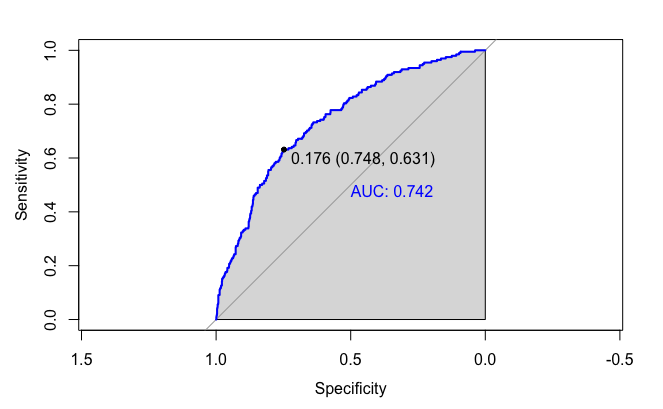

```r
plot(pROC_object, col="blue",
     print.thres = "best",
     print.auc = TRUE,
     auc.polygon = TRUE,
     )
```

## External Validation

Test our model on other cohorts of patients to determine how generalizable our model really is.

## pROC Summary Statistics

```r
# Using the "best" threshold value
coords(pROC_object, "best", ret = c("threshold", "specificity", "sensitivity", "accuracy", "tn", "tp", "fn", "fp", "npv", "ppv", "1-specificity", "1-sensitivity", "1-accuracy", "1-npv", "1-ppv", "precision", "recall"))
```

```
    threshold   specificity   sensitivity      accuracy            tn            tp
   0.17581669    0.74790698    0.63131313    0.72977219  804.00000000  125.00000000
           fn            fp           npv           ppv 1-specificity 1-sensitivity
  73.00000000  271.00000000    0.91676169    0.31565657    0.25209302    0.36868687
   1-accuracy         1-npv         1-ppv     precision        recall
   0.27022781    0.08323831    0.68434343    0.31565657    0.63131313
```

```r
# Using a specific threshold value, e.g. 0.4
coords(pROC_train, 0.4, ret = c("threshold", "specificity", "sensitivity", "accuracy", "tn", "tp", "fn", "fp", "npv", "ppv", "1-specificity", "1-sensitivity", "1-accuracy", "1-npv", "1-ppv", "precision", "recall"))
```

```
    threshold   specificity   sensitivity      accuracy            tn            tp
   0.40000000    0.93243243    0.44000000    0.80808081   69.00000000   11.00000000
           fn            fp           npv           ppv 1-specificity 1-sensitivity
  14.00000000    5.00000000    0.83132530    0.68750000    0.06756757    0.56000000
   1-accuracy         1-npv         1-ppv     precision        recall
   0.19191919    0.16867470    0.31250000    0.68750000    0.44000000
```

```r
# Determine the "local maximas" by using "local maximas" instead of "best"
```

> The `caret` package does a great job of providing summary statistics in a “pretty” output.

# Election Forecasting - Recitation

**Load the dataset**

```r
polling <- read_csv("~/Documents/Online Classes/analytics-edge/PollingData.csv")
glimpse(polling)
```

```
Observations: 145
Variables: 7
$ State      <chr> "Alabama", "Alabama", "Alaska", "Alaska", "Arizona", "Arizona", ...
$ Year       <int> 2004, 2008, 2004, 2008, 2004, 2008, 2012, 2004, 2008, 2012, 2004...
$ Rasmussen  <int> 11, 21, NA, 16, 5, 5, 8, 7, 10, NA, -11, -27, NA, 5, -4, 3, NA, ...
$ SurveyUSA  <int> 18, 25, NA, NA, 15, NA, NA, 5, NA, NA, -11, -24, -14, 3, NA, -2,...
$ DiffCount  <int> 5, 5, 1, 6, 8, 9, 4, 8, 5, 2, -8, -5, -6, 9, -15, -5, -3, -4, -8...
$ PropR      <dbl> 1.0000000, 1.0000000, 1.0000000, 1.0000000, 1.0000000, 1.0000000...
$ Republican <int> 1, 1, 1, 1, 1, 1, 1, 1, 1, 1, 0, 0, 0, 1, 0, 0, 0, 0, 0, 0, 0, 1...
```

Although we expect $150$ (50 states $\times$ 3 elections: 2004, 2008, 2012) observations, you’ll notice that we only have $145$ observations in our dataset. Let’s use the `table` function to see which year(s) have missing data.

```r
table(polling$Year)
```

```
2004 2008 2012
  50   50   45
```

It looks like for the year $2012$, we are missing 5 observations.

## Handling Missing Data

> **Imputation** - fill in *missing* (NA) values based on non-missing values.

We will use the `mice` package to perform imputation for the missing values. Knowing that our missing values pertain to the polling data, let’s subset this as we try to perform our imputation.

```r
summary(sub_polling)
```

```
   Rasmussen          SurveyUSA            PropR          DiffCount
 Min.   :-41.0000   Min.   :-33.0000   Min.   :0.0000   Min.   :-19.000
 1st Qu.: -8.0000   1st Qu.:-11.7500   1st Qu.:0.0000   1st Qu.: -6.000
 Median :  1.0000   Median : -2.0000   Median :0.6250   Median :  1.000
 Mean   :  0.0404   Mean   : -0.8243   Mean   :0.5259   Mean   : -1.269
 3rd Qu.:  8.5000   3rd Qu.:  8.0000   3rd Qu.:1.0000   3rd Qu.:  4.000
 Max.   : 39.0000   Max.   : 30.0000   Max.   :1.0000   Max.   : 11.000
 NA's   :46         NA's   :71
```

We see that ‘Rasmussen’ and ‘SurveyUSA’ have quite a few missing values.

**Perform Imputation**

```r
set.seed(144)
imputed_poll <- complete(mice(sub_polling))
```

```r
summary(imputed_poll)
```

```
   Rasmussen         SurveyUSA           PropR          DiffCount
 Min.   :-41.000   Min.   :-33.000   Min.   :0.0000   Min.   :-19.000
 1st Qu.: -8.000   1st Qu.:-11.000   1st Qu.:0.0000   1st Qu.: -6.000
 Median :  3.000   Median :  1.000   Median :0.6250   Median :  1.000
 Mean   :  1.731   Mean   :  1.517   Mean   :0.5259   Mean   : -1.269
 3rd Qu.: 11.000   3rd Qu.: 18.000   3rd Qu.:1.0000   3rd Qu.:  4.000
 Max.   : 39.000   Max.   : 30.000   Max.   :1.0000   Max.   : 11.000
```

We can now plug our *imputed* ‘Rasmussen’ and ‘SurveyUSA’ columns back into our original dataset, `polling`.

```r
polling$Rasmussen <- imputed_poll$Rasmussen
polling$SurveyUSA <- imputed_poll$SurveyUSA
```

## Create training and test set

- **Training set** - data from 2004, 2008 elections
- **Test set** - data from 2012 election

```r
train <- subset(polling, Year == 2004 | Year == 2008)
test <- subset(polling, Year == 2012)
```

**What is our “baseline” model?**

Our “baseline” model will be the *most common* outcome. Let’s use the `table` function on our training set to determine which outcome this is, i.e. Republican or Democrat.

```r
table(train$Republican)
```

```
 0  1
47 53
```

Here we see that the most common outcome was $1$, i.e. Republican, with $53$. So our “baseline” model will be to go with $1$, i.e. the Republican candidate will win the state. The accuracy of our “baseline” model is expected to be $53/100 = 53$%. This “baseline” model is 💩.

A more reasonable “baseline” model would be to use one of the polls, e.g. Rasmussen, and predict that the party favored by the poll in that particular state would win. Let’s create this *better* “baseline” model now.

```r
# sign() if value is +, gives output +1. If value is -, gives -1. If 0, gives 0.
table( sign(train$Rasmussen) )
```

```
-1  0  1
42  3 55
```

This *better* “baseline” model predicts that in $55$ cases the Republican candidate is predicted to win, in $42$ the Democratic candidate, and in $3$ cases it’s unknown.

**Compare *true* vs “baseline” model predicted election outcomes.**

```r
table(train$Republican, sign(train$Rasmussen))
```

```
    -1  0  1
  0 42  2  3
  1  0  1 52
```

As you can see, our *better* “baseline” model is a much more accurate - 0.94 - than our previous “baseline” model ($53$% accuracy).

## Assess for Correlation

Assess for multicollinearity of the independent variables. Recall, we will use the `cor` function to assess for correlation between these variables.

```r
cor(train[,3:7])
```

```
           Rasmussen SurveyUSA DiffCount     PropR Republican
Rasmussen  1.0000000 0.9194508 0.5124098 0.8404803  0.8021191
SurveyUSA  0.9194508 1.0000000 0.5541816 0.8756581  0.8205806
DiffCount  0.5124098 0.5541816 1.0000000 0.8273785  0.8092777
PropR      0.8404803 0.8756581 0.8273785 1.0000000  0.9484204
Republican 0.8021191 0.8205806 0.8092777 0.9484204  1.0000000
```

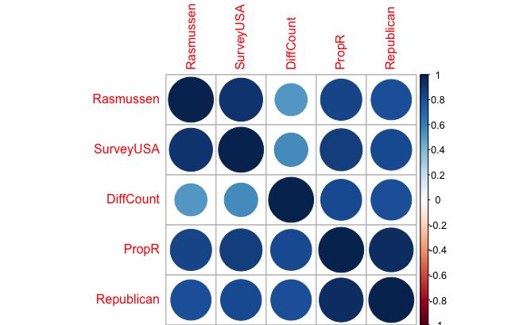

```r
corrplot::corrplot(cor(train[,3:7]))
```

## Feature Selection

Looking at our correlation table, we see that `PropR` has the greatest correaltion with our desired variable, `Republican`.

```r
model1 <- glm(Republican ~ PropR, data = train, family = "binomial")
summary(model1)
```

```
Call:
glm(formula = Republican ~ PropR, family = "binomial", data = train)

Deviance Residuals:
     Min        1Q    Median        3Q       Max
-2.22880  -0.06541   0.10260   0.10260   1.37392

Coefficients:
            Estimate Std. Error z value Pr(>|z|)
(Intercept)   -6.146      1.977  -3.108 0.001882 **
PropR         11.390      3.153   3.613 0.000303 ***
---
Signif. codes:  0 ‘***’ 0.001 ‘**’ 0.01 ‘*’ 0.05 ‘.’ 0.1 ‘ ’ 1

(Dispersion parameter for binomial family taken to be 1)

    Null deviance: 138.269  on 99  degrees of freedom
Residual deviance:  15.772  on 98  degrees of freedom
AIC: 19.772

Number of Fisher Scoring iterations: 8
```

**Compute Predictions with our univariate model**

```r
head(predict1)
```

```
      1       2       3       4       5       6
0.99475 0.99475 0.99475 0.99475 0.99475 0.99475
```

**Compare Predictions vs True Outcomes with threshold 0.5**

```r
table(train$Republican, predict1 >= 0.5)
```

```
    FALSE TRUE
  0    45    2
  1     2   51
```

**Add variables to our model**

```r
summary(model2)
```

```
Call:
glm(formula = Republican ~ SurveyUSA + DiffCount, family = "binomial",
    data = train)

Deviance Residuals:
     Min        1Q    Median        3Q       Max
-2.01196  -0.00698   0.01005   0.05074   1.54975

Coefficients:
            Estimate Std. Error z value Pr(>|z|)
(Intercept)  -1.1405     1.2456  -0.916   0.3599
SurveyUSA     0.2976     0.1949   1.527   0.1267
DiffCount     0.7673     0.4188   1.832   0.0669 .
---
Signif. codes:  0 ‘***’ 0.001 ‘**’ 0.01 ‘*’ 0.05 ‘.’ 0.1 ‘ ’ 1

(Dispersion parameter for binomial family taken to be 1)

    Null deviance: 138.269  on 99  degrees of freedom
Residual deviance:  12.439  on 97  degrees of freedom
AIC: 18.439

Number of Fisher Scoring iterations: 10
```

This model is a bit stronger than our previous model (judging by the *decrease* in AIC of our current model compared to the previous model). However, the downside is that neither of the independent variables is *significant*.

**Is our new model *more* accurate than our previous (univariate) model?**

```r
table(train$Republican, predict2 > 0.5)
```

```
    FALSE TRUE
  0    45    2
  1     1   52
```

This *new* model makes 1 fewer mistake than our previous model did.

## Test Set Predictions

**Compare *true* outcomes to our *improved* “baseline” model**

```r
table(test$Republican, sign(test$Rasmussen))
```

```
    -1  0  1
  0 18  2  4
  1  0  0 21
```

**Compute test set predictions with `model2`**

```r
predict_test <- predict(model2, newdata = test, type = "response")
```

**Compare *true* outcomes versus *predicted* outcomes (at threshold 0.5)**

```r
table(test$Republican, predict_test > 0.5)
```

```
    FALSE TRUE
  0    23    1
  1     0   21
```

**Identify the 1 error our model made**

| State | Year | Rasmussen | SurveyUSA | DiffCount | PropR | Republican |
| --- | --- | --- | --- | --- | --- | --- |
| Florida | 2012 | 2 | 0 | 6 | 0.6666667 | 0 |